# Lab 6 ML Workflows

Author

Sean Pearson

Published

April 5, 2025

```r
library(tidyverse)
library(tidymodels)
library(powerjoin)
library(glue)
library(vip)
library(baguette)
```

```r
# Download the CAMELS documentation PDF
download.file(
  url = "https://gdex.ucar.edu/dataset/camels/file/camels_attributes_v2.0.pdf",
  destfile = "data/camels_attributes_v2.0.pdf",
  mode = "wb"
)
```

```r
# Define the file types we want
types <- c("clim", "geol", "soil", "topo", "vege", "hydro")

# Root URL and file paths
root <- "https://gdex.ucar.edu/dataset/camels/file"
remote_files <- glue("{root}/camels_{types}.txt")
local_files  <- glue("data/camels_{types}.txt")

# Download each .txt file to the data folder
walk2(remote_files, local_files, ~ download.file(.x, .y, quiet = TRUE))
```

```r
# Read each .txt file
camels_list <- map(local_files, ~ read_delim(.x, show_col_types = FALSE))
```

```r
# Merge all data frames
camels <- power_full_join(camels_list, by = "gauge_id")
```

## Question 1:

#### Part 1: From the documentation PDF, report what zero_q_freq represents

This represents the frequency of days with Q = 0 mm/day. In other words, the percentage of days in the streamflow record when streamflow was zero at the gauge.

## Question 2:

```r
library(ggplot2)
library(patchwork)
library(maps)
library(ggthemes)
```

```r
# Add US state borders
base_map <- borders("state", colour = "gray50")
```

#### Part 1: Create Aridity Map

```r
# Map 1: Color by aridity
map_aridity <- ggplot(camels, aes(x = gauge_lon, y = gauge_lat)) +
  base_map +
  geom_point(aes(color = aridity)) +
  scale_color_gradient(low = "lightyellow", high = "darkred") +
  ggtitle("Site Aridity") +
  theme_map()
```

#### Part 2: Create p_mean Map

```r
# Map 2: Color by p_mean
map_pmean <- ggplot(camels, aes(x = gauge_lon, y = gauge_lat)) +
  base_map +
  geom_point(aes(color = p_mean)) +
  scale_color_gradient(low = "lightblue", high = "darkblue") +
  ggtitle("Mean Precipitation (p_mean)") +
  theme_map()
```

#### Part 3: Combine the Maps

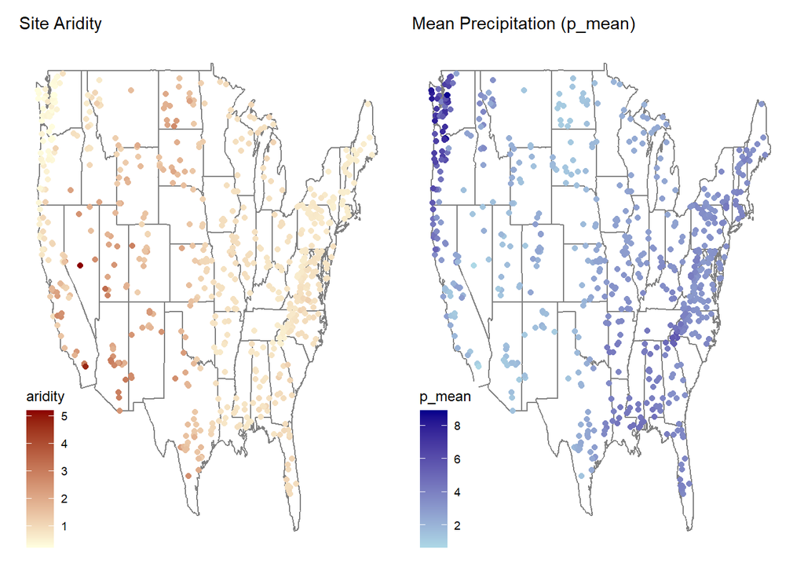

```r
# Combine the two plots sidebyside
map_aridity + map_pmean
```

## Question 3:

```r
# Load if not already
library(xgboost)
library(ranger)
```

```r
# Make sure logQmean exists
camels <- camels %>%
  mutate(logQmean = log(q_mean))
```

```r
# Split the data
set.seed(123)
camels_split <- initial_split(camels, prop = 0.8)
camels_train <- training(camels_split)
camels_test  <- testing(camels_split)
```

```r
# 10-fold CV
camels_cv <- vfold_cv(camels_train, v = 10)
```

```r
rec <- recipe(logQmean ~ aridity + p_mean, data = camels_train) %>%
  step_log(all_predictors()) %>%
  step_interact(terms = ~ aridity:p_mean) %>%
  step_naomit(all_predictors(), all_outcomes())
```

```r
# Linear regression
lm_model <- linear_reg() %>%
  set_engine("lm") %>%
  set_mode("regression")
```

```r
# Random forest
rf_model <- rand_forest() %>%
  set_engine("ranger", importance = "impurity") %>%
  set_mode("regression")
```

#### Part 1: Build an xgboost Model

```r
# XGBoost
xgb_model <- boost_tree() %>%
  set_engine("xgboost") %>%
  set_mode("regression")
```

#### Part 2: Build a Neural Network Model

```r
# Neural Net via bagged MLP
nnet_model <- bag_mlp() %>%
  set_engine("nnet") %>%
  set_mode("regression")
```

#### Part 3: Add All Four Models to Workflow

```r
wf <- workflow_set(
  preproc = list(rec),
  models = list(
    linear_reg = lm_model,
    random_forest = rf_model,
    xgboost = xgb_model,
    neural_net = nnet_model
  )
) %>%
  workflow_map("fit_resamples", resamples = camels_cv)
```

#### Part 4: Compare Model Performance and Evaluation

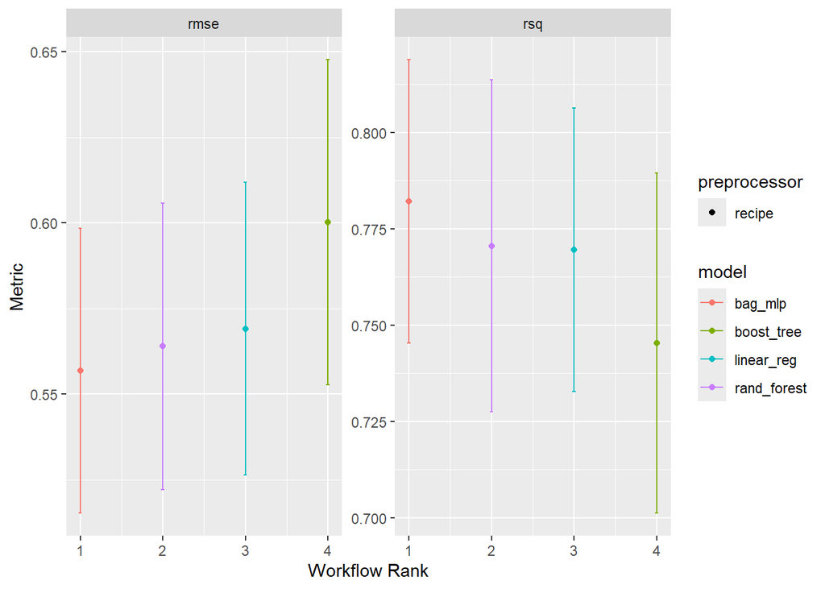

```r
# Plot performance across models
autoplot(wf)
```

```r
# Rank by R²
rank_results(wf, rank_metric = "rsq", select_best = TRUE)
```

```
# A tibble: 8 × 9
  wflow_id          .config .metric  mean std_err     n preprocessor model  rank
  <chr>             <chr>   <chr>   <dbl>   <dbl> <int> <chr>        <chr> <int>
1 recipe_neural_net Prepro… rmse    0.557  0.0253    10 recipe       bag_…     1
2 recipe_neural_net Prepro… rsq     0.782  0.0224    10 recipe       bag_…     1
3 recipe_random_fo… Prepro… rmse    0.564  0.0254    10 recipe       rand…     2
4 recipe_random_fo… Prepro… rsq     0.771  0.0262    10 recipe       rand…     2
5 recipe_linear_reg Prepro… rmse    0.569  0.0260    10 recipe       line…     3
6 recipe_linear_reg Prepro… rsq     0.770  0.0223    10 recipe       line…     3
7 recipe_xgboost    Prepro… rmse    0.600  0.0289    10 recipe       boos…     4
8 recipe_xgboost    Prepro… rsq     0.745  0.0268    10 recipe       boos…     4
```

Model Evaluation and Comparison I compared four models: linear regression, random forest, xgboost, and a neural network. The neural network model (bag_mlp) performed the best, with the lowest RMSE (0.557) and highest r-squared (0.782). This means it made the most accurate predictions and explained the most variation in the data. Random forest came in second, followed by linear regression. xgboost had the lowest performance. Based on this, I would choose the neural network model to move forward with.

#### Part 5: Conclusion

Based on my results, the model I should move forward with is bag_mlp.

## Build Your Own:

#### Part 1: Data Splitting

```r
# Set seed
set.seed(42)  # New seed to show it’s a different split
```

```r
# Create log-transformed target variable
camels <- camels %>%
  mutate(logQmean = log(q_mean))
```

```r
# New 75/25 split for Build Your Own section
camels_split_byo <- initial_split(camels, prop = 0.75)
camels_train_byo <- training(camels_split_byo)
camels_test_byo  <- testing(camels_split_byo)
```

```r
# New 10-fold CV
camels_cv_byo <- vfold_cv(camels_train_byo, v = 10)
```

#### Part 2: Recipe

I will be using the formula logQmean ~ p_mean + pet_mean + slope_mean + frac_forest. I chose this formula because these variables because they all affect how much water flows in a river:

- p_mean = how much rain falls
- pet_mean = how much water goes back into the air
- slope_mean = how steep the land is
- frac_forest = how much of the land is covered by trees

These things all impact how much water ends up in the stream, so they help predict streamflow.

```r
rec_byo <- recipe(logQmean ~ p_mean + pet_mean + slope_mean + frac_forest, data = camels_train_byo) %>%
  step_mutate(frac_forest = ifelse(is.finite(frac_forest), frac_forest, NA)) %>%
  step_naomit(all_predictors(), all_outcomes()) %>%
  step_normalize(all_predictors())
```

#### Part 3: Define 3 Models

```r
# Random Forest model
rf_model_byo <- rand_forest() %>%
  set_engine("ranger", importance = "impurity") %>%
  set_mode("regression")
```

```r
# XGBoost model
xgb_model_byo <- boost_tree() %>%
  set_engine("xgboost") %>%
  set_mode("regression")
```

```r
# Neural Network (bagged MLP) model
nnet_model_byo <- bag_mlp() %>%
  set_engine("nnet") %>%
  set_mode("regression")
```

#### Part 4: Workflow Set

```r
# Create a named list of models
models_byo <- list(
  random_forest = rf_model_byo,
  xgboost = xgb_model_byo,
  neural_net = nnet_model_byo
)

# Create a workflow set using the same recipe for all models
wf_byo <- workflow_set(
  preproc = list(recipe = rec_byo),
  models  = models_byo
)

# Fit all models to 10-fold CV resamples
wf_byo_results <- wf_byo %>%
  workflow_map("fit_resamples", resamples = camels_cv_byo)
```

#### Part 5: Evaluation

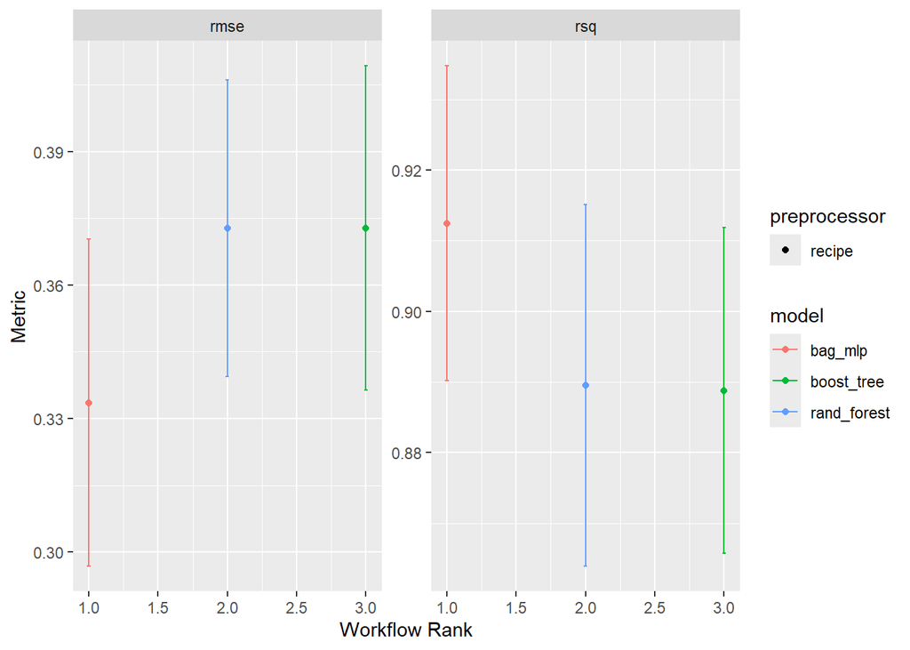

```r
# Visualize performance
autoplot(wf_byo_results)
```

```r
# Show best model by R-squared
rank_results(wf_byo_results, rank_metric = "rsq", select_best = TRUE)
```

```
# A tibble: 6 × 9
  wflow_id          .config .metric  mean std_err     n preprocessor model  rank
  <chr>             <chr>   <chr>   <dbl>   <dbl> <int> <chr>        <chr> <int>
1 recipe_neural_net Prepro… rmse    0.334  0.0224    10 recipe       bag_…     1
2 recipe_neural_net Prepro… rsq     0.912  0.0135    10 recipe       bag_…     1
3 recipe_random_fo… Prepro… rmse    0.373  0.0202    10 recipe       rand…     2
4 recipe_random_fo… Prepro… rsq     0.889  0.0156    10 recipe       rand…     2
5 recipe_xgboost    Prepro… rmse    0.373  0.0221    10 recipe       boos…     3
6 recipe_xgboost    Prepro… rsq     0.889  0.0140    10 recipe       boos…     3
```

Based on the results I can conclude that bag_mlp is the most accurate model. This is due to the fact that it has the lowest rmse and highest r-squared. Low rmse values mean better predictions and r-squared values that are near 1 better fit the model.

#### Step 6: Extract and Evaluate

```r
# Build a workflow with the best model and recipe
final_wf <- workflow() %>%
  add_model(nnet_model_byo) %>%   # bag_mlp model you defined earlier
  add_recipe(rec_byo)             # recipe you built earlier
```

```r
# Fit the model to all training data
final_fit <- fit(final_wf, data = camels_train_byo)
```

```r
# Predict on the test data
final_preds <- augment(final_fit, new_data = camels_test_byo)
```

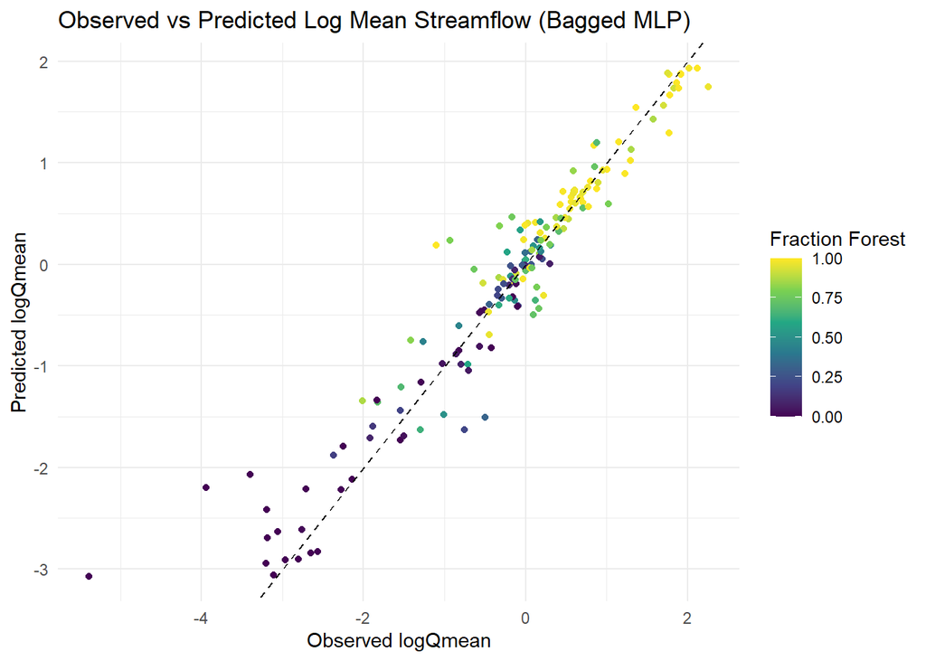

```r
# Plot observed vs predicted values
ggplot(final_preds, aes(x = logQmean, y = .pred, color = frac_forest)) +
  geom_point() +
  geom_abline(linetype = "dashed", color = "black") +
  scale_color_viridis_c() +
  labs(
    title = "Observed vs Predicted Log Mean Streamflow (Bagged MLP)",
    x = "Observed logQmean",
    y = "Predicted logQmean",
    color = "Fraction Forest"
  ) +
  theme_minimal()
```

The bagged MLP model did a great job predicting mean streamflow. Most of the points are close to the dashed line, which means the predictions are very similar to the real values. The color scale (Fraction Forest) also looks well spread out, so the model seems to work across different land cover types. Overall, the model looks accurate and should do well predicting streamflow in similar places.